# Ductular Reaction

Lluís Revilla

2017-01-12

# 1 Introduction

This data was extracted from a liver, the POS labels indicate that were extracted from a microdisection with KRT7 positive. NEG indicates that for the same microdisection those not stained for KRT7 where taken. TOTAL indicates that there is a mix of KRT7+ and KRT7- dyeing.

This is part of a bigger study you can find here

# 2 Load the data

```r
phenoData <- read.csv("../data/ductular_reaction/PHENO_26_10_2015.csv",
                      row.names = 1)
expression <- read.delim("../data/ductular_reaction/refseq_counts_DR.csv",
                         row.names = 1)
```

We explore these data:

```r
library("geneplotter")
summary(phenoData)
```

```
##       NAME        G        POS_NEG      POS_TOTAL     NEG_TOTAL
##  GTB140 : 1   NEG  :6   Min.   :1.0   Min.   :1.0   Min.   :1.0
##  GTB141 : 1   POS  :6   1st Qu.:1.0   1st Qu.:1.0   1st Qu.:1.0
##  GTB142 : 1   TOTAL:4   Median :1.5   Median :2.0   Median :2.0
##  GTB143 : 1             Mean   :1.5   Mean   :1.6   Mean   :1.6
##  GTB144 : 1             3rd Qu.:2.0   3rd Qu.:2.0   3rd Qu.:2.0
##  GTB145 : 1             Max.   :2.0   Max.   :2.0   Max.   :2.0
##  (Other):10             NA's   :4     NA's   :6     NA's   :6
```

```r
phenoData
```

```
##                                                       NAME     G POS_NEG
## 367_positivo_IonXpress_017.GTB0140_collapsed_uq.sam GTB140   POS       2
## 377_positivo_IonXpress_018.GTB0141_collapsed_uq.sam GTB141   POS       2
## 408_positivo_IonXpress_019.GTB0142_collapsed_uq.sam GTB142   POS       2
## 383_positivo_GTB198.IonXpress_009_collapsed_uq.sam  GTB198   POS       2
## 409_positivo_GTB199.IonXpress_010_collapsed_uq.sam  GTB199   POS       2
## 410_positivo_GTB200.IonXpress_011_collapsed_uq.sam  GTB200   POS       2
## 367_negativo_IonXpress_020.GTB0143_collapsed_uq.sam GTB143   NEG       1
## 377_negativo_IonXpress_021.GTB0144_collapsed_uq.sam GTB144   NEG       1
## 408_negativo_IonXpress_022.GTB0145_collapsed_uq.sam GTB145   NEG       1
## 383_negativo_GTB201.IonXpress_012_collapsed_uq.sam  GTB201   NEG       1
## 409_negativo_GTB202.IonXpress_013_collapsed_uq.sam  GTB202   NEG       1
## 410_negativo_GTB203.IonXpress_014_collapsed_uq.sam  GTB203   NEG       1
## 377_total_IonXpress_023.GTB0146_collapsed_uq.sam    GTB146 TOTAL      NA
## 408_total_IonXpress_024.GTB0147_collapsed_uq.sam    GTB147 TOTAL      NA
## 409_total_GTB204.IonXpress_015_collapsed_uq.sam     GTB204 TOTAL      NA
## 410_total_GTB205.IonXpress_016_collapsed_uq.sam     GTB205 TOTAL      NA
##                                                     POS_TOTAL NEG_TOTAL
## 367_positivo_IonXpress_017.GTB0140_collapsed_uq.sam         2        NA
## 377_positivo_IonXpress_018.GTB0141_collapsed_uq.sam         2        NA
## 408_positivo_IonXpress_019.GTB0142_collapsed_uq.sam         2        NA
## 383_positivo_GTB198.IonXpress_009_collapsed_uq.sam          2        NA
## 409_positivo_GTB199.IonXpress_010_collapsed_uq.sam          2        NA
## 410_positivo_GTB200.IonXpress_011_collapsed_uq.sam          2        NA
## 367_negativo_IonXpress_020.GTB0143_collapsed_uq.sam        NA         2
## 377_negativo_IonXpress_021.GTB0144_collapsed_uq.sam        NA         2
## 408_negativo_IonXpress_022.GTB0145_collapsed_uq.sam        NA         2
## 383_negativo_GTB201.IonXpress_012_collapsed_uq.sam         NA         2
## 409_negativo_GTB202.IonXpress_013_collapsed_uq.sam         NA         2
## 410_negativo_GTB203.IonXpress_014_collapsed_uq.sam         NA         2
## 377_total_IonXpress_023.GTB0146_collapsed_uq.sam            1         1
## 408_total_IonXpress_024.GTB0147_collapsed_uq.sam            1         1
## 409_total_GTB204.IonXpress_015_collapsed_uq.sam             1         1
## 410_total_GTB205.IonXpress_016_collapsed_uq.sam             1         1
```

```r
expression[1:5, 1:5]
```

```
##           IonXpress_017.GTB0140_collapsed_uq.sam
## NR_039978                                      5
## NM_130786                                    595
## NM_138932                                    226
## NM_033110                                      0
## NM_000014                                   3147
##           IonXpress_018.GTB0141_collapsed_uq.sam
## NR_039978                                      7
## NM_130786                                    248
## NM_138932                                     94
## NM_033110                                      0
## NM_000014                                   4269
##           IonXpress_019.GTB0142_collapsed_uq.sam
## NR_039978                                     20
## NM_130786                                   1038
## NM_138932                                    249
## NM_033110                                     15
## NM_000014                                   5128
##           X383_positivo_GTB198.IonXpress_009_collapsed_uq.sam
## NR_039978                                                  11
## NM_130786                                                2556
## NM_138932                                                 317
## NM_033110                                                  11
## NM_000014                                                7466
##           X409_positivo_GTB199.IonXpress_010_collapsed_uq.sam
## NR_039978                                                  48
## NM_130786                                                 345
## NM_138932                                                 570
## NM_033110                                                   0
## NM_000014                                                4666
```

We can observe the expression uses the RefSeq identifier of NCBI. And that there is a sample identification in the name of the samples, I proceed to create its own column:

```r
phenoData$paired <- as.numeric(substring(rownames(phenoData), 0, 3))
```

We can calculate the normalization factors used to calculate the Counts per million read:

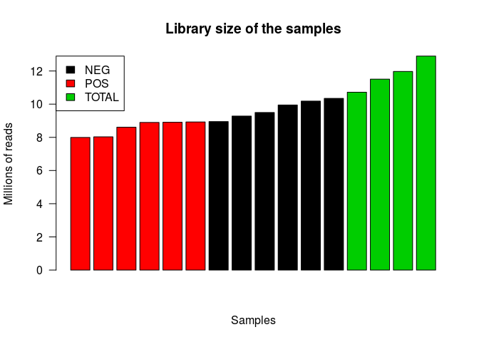

```r
library("edgeR")
dge <- DGEList(counts = expression, group = phenoData$G)
ord <- order(dge$sample$lib.size)
barplot(dge$sample$lib.size[ord]/1e6, las = 1, ylab = "Millions of reads",
        xlab = "Samples", main = "Library size of the samples", col = phenoData$G)
legend("topleft", legend = levels(phenoData$G),
       fill = seq_along(levels(phenoData$G)))
```

```r
dge <- calcNormFactors(dge)
```

We can normalize the data to counts per millon of reads taking into account that we know the normalized library size:

```r
logCPM <- cpm(dge, normalized.lib.sizes = TRUE, log = TRUE, prior.count = 3)
```

# 3 Check quality pre-normalizations

We can observe the quality of the samples with a boxplot and the density of expressions:

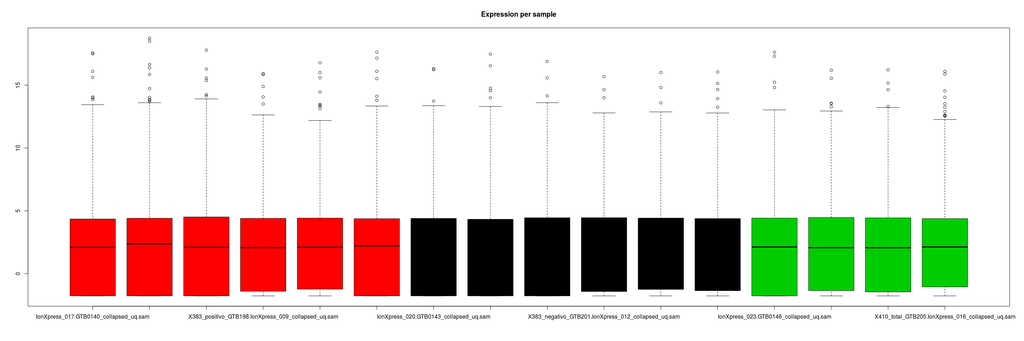

```r
boxplot(logCPM, main = "Expression per sample", col = phenoData$G)
```

```r
multidensity(logCPM, main = "Densities of expression", legend = phenoData$G,
             col = phenoData$G)
```

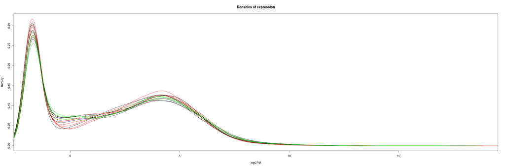

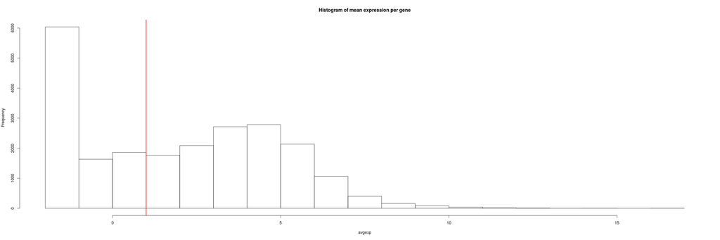

```r
avgexp <- rowMeans(logCPM)
hist(avgexp, main = "Histogram of mean expression per gene")
abline(v = 1, col = "red", lwd = 2)
```

There is a lot of differences between samples on the low expressed genes. We filter those genes that are below 1, as they are unreliable:

```r
logCPM <- logCPM[avgexp > 1, ]
multidensity(logCPM, main = "Densities of expression", legend = NULL)
```

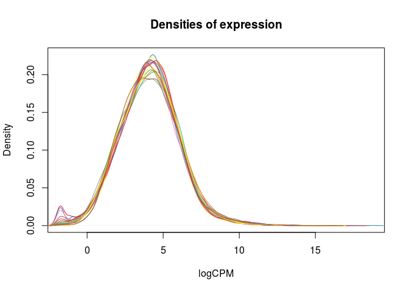

Now the distribution of the expression between samples is much more comparable. Following the recomendation of the edgeR package we recalculate the normalization factor without the lowly expressed genes:

```r
dge <- calcNormFactors(dge[avgexp > 1, ])
logCPM <- cpm(dge, normalized.lib.sizes = TRUE, log = TRUE, prior.count = 3)
```

We can check how has this normalization affected the values:

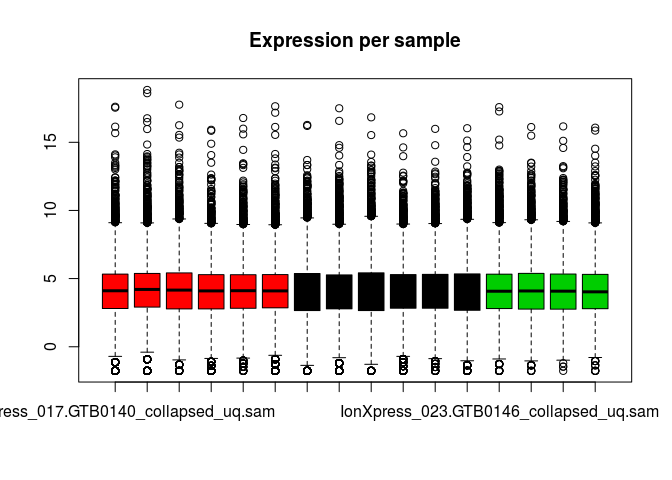

```r
boxplot(logCPM, main = "Expression per sample", col = phenoData$G)
```

```r
multidensity(logCPM, main = "Densities of expression", legend = NULL)
```

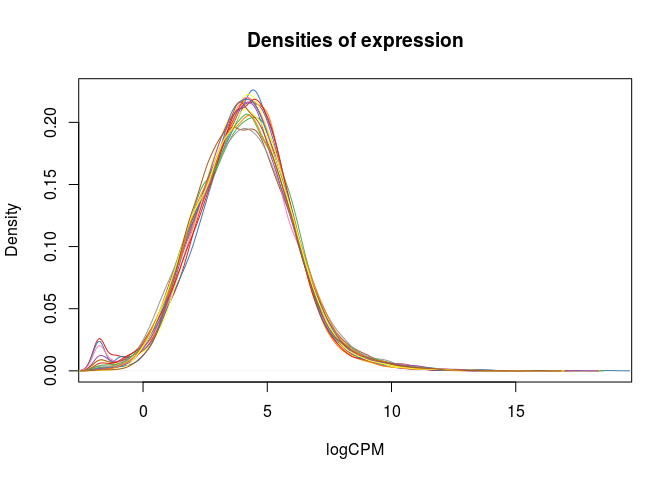

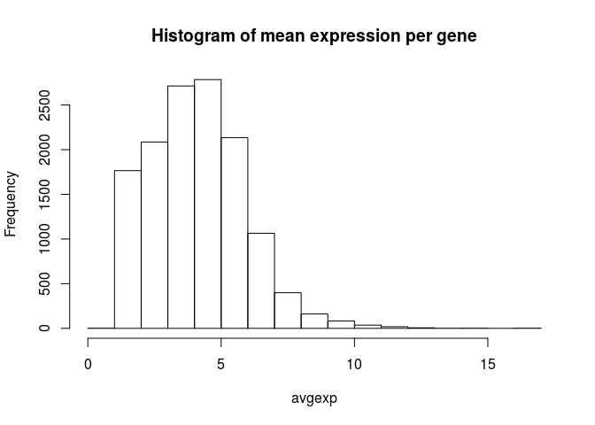

```r
avgexp <- rowMeans(logCPM)
hist(avgexp, main = "Histogram of mean expression per gene")
```

Now are a little bit more comparable.  
To work easier with the data I proceed to create an ExpressionSet

```r
library("Biobase")
library("AnnotationDbi")
DR <- ExpressionSet(as.matrix(logCPM))
phenoData(DR) <- AnnotatedDataFrame(phenoData)
DR
```

```
## ExpressionSet (storageMode: lockedEnvironment)
## assayData: 13254 features, 16 samples
##   element names: exprs
## protocolData: none
## phenoData
##   rowNames: 367_positivo_IonXpress_017.GTB0140_collapsed_uq.sam
##     377_positivo_IonXpress_018.GTB0141_collapsed_uq.sam ...
##     410_total_GTB205.IonXpress_016_collapsed_uq.sam (16 total)
##   varLabels: NAME G ... paired (6 total)
##   varMetadata: labelDescription
## featureData: none
## experimentData: use 'experimentData(object)'
## Annotation:
```

# 4 Check the normalizations applied

We take advantatge of the plotMDS function of limma package to plot the MDS of the samples, to see how close are between them.

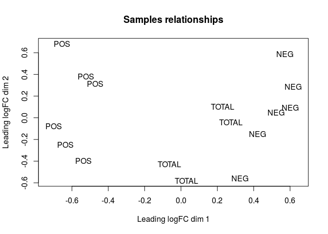

```r
plotMDS(DR, top = Inf, labels = phenoData(DR)$G, main = "Samples relationships")
```

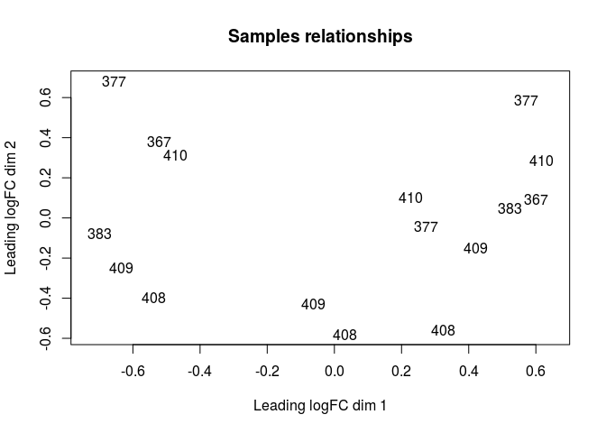

```r
plotMDS(DR, top = Inf, labels = phenoData(DR)$paired, main = "Samples relationships")
```

We can visualize too, the relationship between samples at gene expression by:

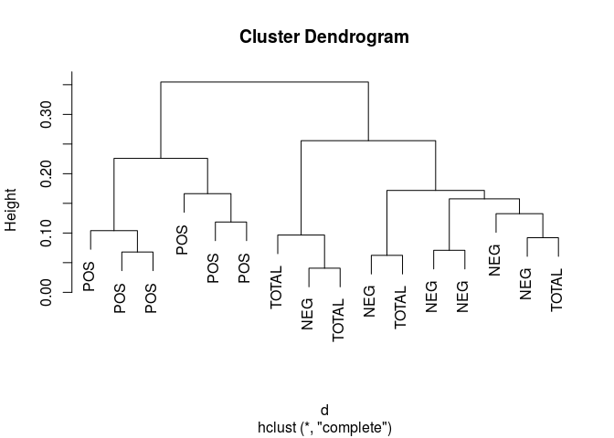

```r
colnames(logCPM) <- phenoData(DR)$G
d <- as.dist(1 - cor(logCPM, method = "spearman"))
cluster <- hclust(d)
plot(cluster)
```

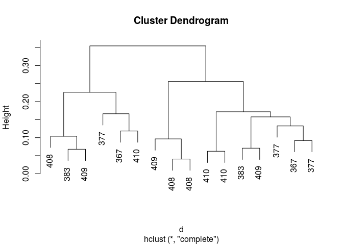

```r
colnames(logCPM) <- phenoData(DR)$paired
d <- as.dist(1 - cor(logCPM, method = "spearman"))
cluster <- hclust(d)
plot(cluster)
```

```r
colnames(logCPM) <- rownames(phenoData(DR))
```

We can see that some samples tend to be paired by the origin of their data.

# 5 Design

```r
# Grouping by sample origin
design <- model.matrix(~0 + phenoData(DR)$G)
colnames(design) <- c("NEG", "POS", "TOTAL")
# Adding covariate of patient origin
# design <- cbind(design, "paired" = phenoData(DR)$paired)
design0 <- matrix(1, nrow = nrow(design))
colnames(design0) <- "Intercept"
design
```

```
##    NEG POS TOTAL
## 1    0   1     0
## 2    0   1     0
## 3    0   1     0
## 4    0   1     0
## 5    0   1     0
## 6    0   1     0
## 7    1   0     0
## 8    1   0     0
## 9    1   0     0
## 10   1   0     0
## 11   1   0     0
## 12   1   0     0
## 13   0   0     1
## 14   0   0     1
## 15   0   0     1
## 16   0   0     1
## attr(,"assign")
## [1] 1 1 1
## attr(,"contrasts")
## attr(,"contrasts")$`phenoData(DR)$G`
## [1] "contr.treatment"
```

And we can adjust the data using the weights previously calculated and the design we just created:

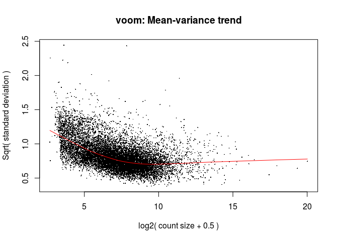

```r
v <- voom(dge, design, plot = TRUE, normalize.method = "cyclicloess")
```

We can see that the adjusted value:

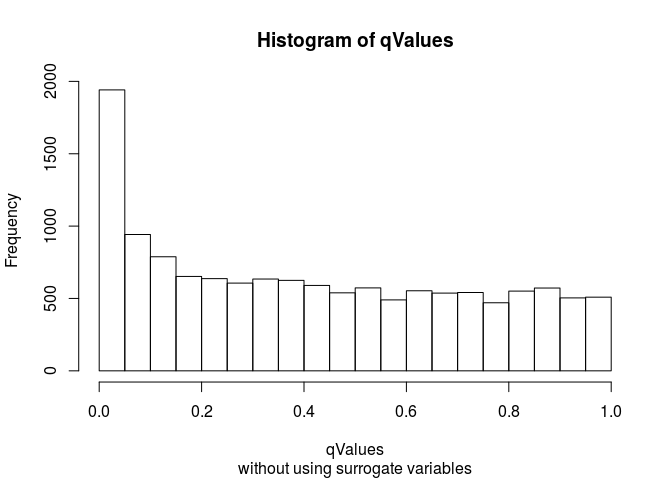

```r
library("sva")
pValues <- f.pvalue(v$E, design, design0)
qValues <- p.adjust(pValues, method = "BH")
hist(qValues, sub = "without using surrogate variables")
```

As we can see, there is a peak in the low p-values for real differentially expressed genes.

# 6 Estimate surrogate variables

We can estimate surrogate variables with the function sva:

```r
sv <- sva(v$E, design, design0, method = "irw")
```

```
## Number of significant surrogate variables is:  5
## Iteration (out of 5 ):1  2  3  4  5
```

We can append the estimated surrogated variables to the design matrix for a better estimation of the effect of each paramter:

```r
i.design <- cbind(design, sv$sv)
colnames(i.design) <- c(colnames(design), paste0("X", 1:ncol(sv$sv)))
i.design0 <- cbind(design0, sv$sv)
colnames(i.design0) <- c(colnames(design0), paste0("X", 1:ncol(sv$sv)))
```

We can check if now using the estimated surrogate variables makes the null hypothesis more uniform than previously:

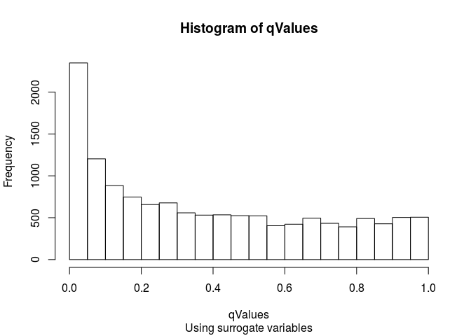

```r
pValues <- f.pvalue(v$E, i.design, i.design0)
qValues <- p.adjust(pValues, method = "BH")
hist(qValues, sub = "Using surrogate variables")
```

Even after adjusting for surrogate variables it doesn’t improve the model. Maybe because we expect big differences between KRT+ and KRT- samples. We fit the design with the expression of the ductular reaction, without taking into account the surrogate variables

```r
fit <- lmFit(v$E, design)
```

# 7 Contrasts

We are interested in the Positive vs Negative comparison, but we can compute others too:

```r
contrasts <- makeContrasts("PosVsNeg" = POS - NEG,
                           "PosVsTotal" = POS - TOTAL,
                           "NegVsTotal" = NEG - TOTAL,
                           levels = design)
contrasts
```

```
##        Contrasts
## Levels  PosVsNeg PosVsTotal NegVsTotal
##   NEG         -1          0          1
##   POS          1          1          0
##   TOTAL        0         -1         -1
```

```r
fit.2 <- contrasts.fit(fit, contrasts)
fit.2 <- eBayes(fit.2)
results.DR <- decideTests(fit.2, adjust.method = "BH", lfc = log2(2))
summary(results.DR)
```

```
##    PosVsNeg PosVsTotal NegVsTotal
## -1     1306        314         98
## 0     10787      12657      13155
## 1      1161        283          1
```

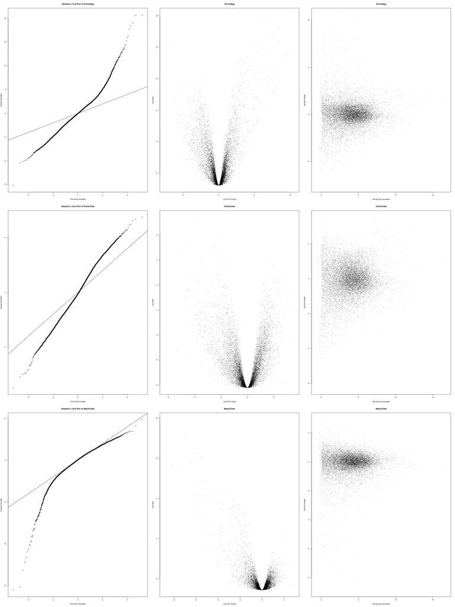

```r
par(mfrow = c(3, 3))
out <- sapply(colnames(results.DR), function(x){
  qqt(fit.2$t[, x], df = fit.2$df.total, main = paste("Student's t Q-Q Plot of", x))
  abline(0, 1)
  volcanoplot(fit.2, coef = x, main = x)
  plotMD(fit.2, coef = x, main = x)
})
```

# 8 Store the data

We store the data in case we need it:

```r
save(fit, fit.2, design, logCPM, DR, contrasts, file = "DR.RData")
```

# 9 Differentially expressed genes

```r
tt.DR <- topTable(fit.2, coef = "PosVsNeg", sort.by = "logFC", number = Inf)
tt.DR <- tt.DR[order(-abs(tt.DR$logFC)), ] # Ordered by the absolute value of logFC
head(tt.DR)
```

```
##               logFC   AveExpr        t      P.Value    adj.P.Val        B
## NM_018646 10.543326 2.5692738 20.69741 2.443811e-13 1.662785e-09 20.10073
## NM_005961 10.040546 5.0005429 13.49972 2.076176e-10 1.896792e-07 14.10159
## NM_000492  9.679275 2.6968851 13.47042 2.146664e-10 1.896792e-07 14.07023
## NM_024320  9.338724 1.6780819 13.27972 2.671771e-10 2.213228e-07 13.86438
## NM_003015  8.851699 1.2323319 12.75549 4.943609e-10 3.233471e-07 13.28263
## NM_020387  8.506945 0.4059383 15.21559 3.247021e-11 5.322958e-08 15.82239
```

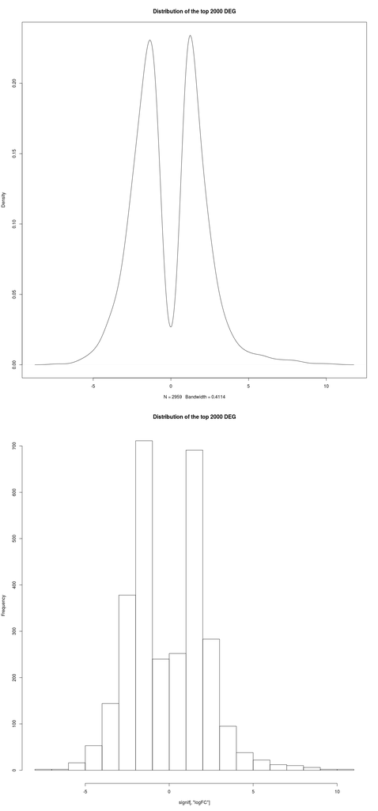

```r
signif <- tt.DR[tt.DR$adj.P.Val < 0.05, ] # Subset of significant p-value
par(mfrow = c(2, 1))
plot(density(signif[, "logFC"]), main = "Distribution of the top 2000 DEG")
hist(signif[, "logFC"], main = "Distribution of the top 2000 DEG")
```

In order to store them we use the symbols, somehow a little bit more informative than the numbers:

```r
library("org.Hs.eg.db")
symb <- mapIds(org.Hs.eg.db, keys = rownames(tt.DR), keytype = "REFSEQ", column = "SYMBOL")
nam <- mapIds(org.Hs.eg.db, keys = rownames(tt.DR), keytype = "REFSEQ", column = "GENENAME")
DEG <- cbind("Symbol" = symb, "Name" = nam, tt.DR)
write.csv(DEG, file = "DR_PosVsNeg.csv", na = "", row.names = FALSE)
```

We stored all the table with 13254 genes, even though some are not significant and there might be some sequences that come from the same gene but with a different messenger.

We can check that KRT7 is more expressed on the positive samples:

```r
DEG[grep("(KRT[0-9])", DEG$Symbol), ]
```

```
##            Symbol                    Name     logFC   AveExpr        t
## NM_005556    KRT7               keratin 7 8.0806383 4.5376056 9.438337
## NM_002276   KRT19              keratin 19 4.5468412 3.2003296 5.414898
## NM_182507   KRT80              keratin 80 3.5817059 0.8301954 3.383675
## NM_000422   KRT17              keratin 17 2.9539608 1.0625844 2.018900
## NM_015515   KRT23              keratin 23 1.9699425 6.4461912 4.569633
## NR_001443 KRT17P5 keratin 17 pseudogene 5 1.8626318 1.5766070 2.598049
## NR_027713 KRT8P41 keratin 8 pseudogene 41 1.7260544 0.5394699 2.975683
## NM_002273    KRT8               keratin 8 1.6764825 6.9130391 4.491307
## NM_000224   KRT18              keratin 18 1.3142865 8.6049975 2.794140
## NM_002284   KRT86              keratin 86 1.1139745 0.1845571 1.328200
## NR_036685 KRT19P2 keratin 19 pseudogene 2 0.6813723 1.0910196 1.032629
##                P.Value    adj.P.Val          B
## NM_005556 4.203215e-08 0.0000073795  8.9790595
## NM_002276 4.940518e-05 0.0010706529  1.9270589
## NM_182507 3.604182e-03 0.0224487235 -2.3273320
## NM_000422 5.985245e-02 0.1592940409 -4.9753768
## NM_015515 2.840788e-04 0.0036805287  0.1794063
## NR_001443 1.894679e-02 0.0724108320 -3.9184139
## NR_027713 8.608872e-03 0.0415520706 -3.1690956
## NM_002273 3.352622e-04 0.0041144128  0.0144970
## NM_000224 1.261356e-02 0.0546697769 -3.5338250
## NM_002284 2.019823e-01 0.3595317876 -6.0068526
## NR_036685 3.165035e-01 0.4842893619 -6.3440106
```

As we would expect, and it is not far from the max log fold-change 10.5433258, in fact is the 9th gene more over-expressed.

# 10 Functional enrichment

We can check for functional enrichment, to see if those few significant genes are more related to performing certain functions and processes. I check for pathways using the Reactome data base and the process using Gene Ontologies.

## 10.1 Reactome

We can see in Reactome which pathways are enriched for those genes, that are significantly differentially expressed.

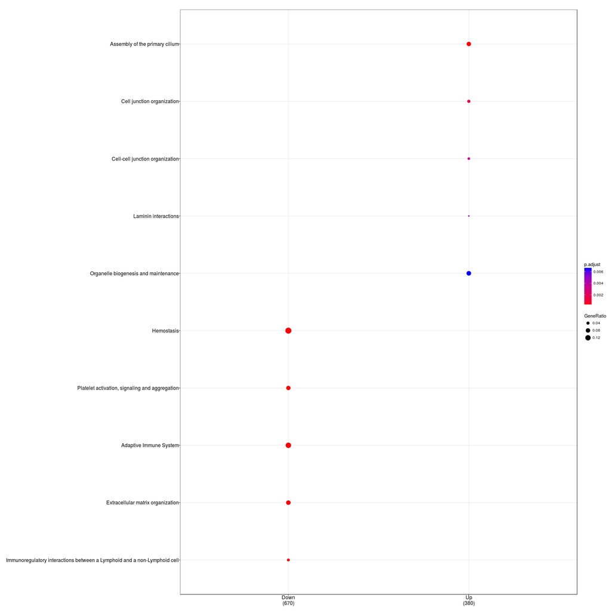

```r
library("ReactomePA")
library("clusterProfiler")
DEG_up <- mapIds(org.Hs.eg.db, keys = rownames(signif[signif$logFC > 0L, ]),
                 keytype = "REFSEQ", column = "ENTREZID")
## 'select()' returned 1:1 mapping between keys and columns
DEG_down <- mapIds(org.Hs.eg.db, keys = rownames(signif[signif$logFC < 0L, ]),
                   keytype = "REFSEQ", column = "ENTREZID")
## 'select()' returned 1:1 mapping between keys and columns
groups <- list(Up = DEG_up, Down = DEG_down)
cc <- compareCluster(groups, fun = "enrichPathway")
dotplot(cc)
```

We can observe differences in the comparison between genes up-regulated and dow-regulated. But for a more general overview is better to see all the genes involved

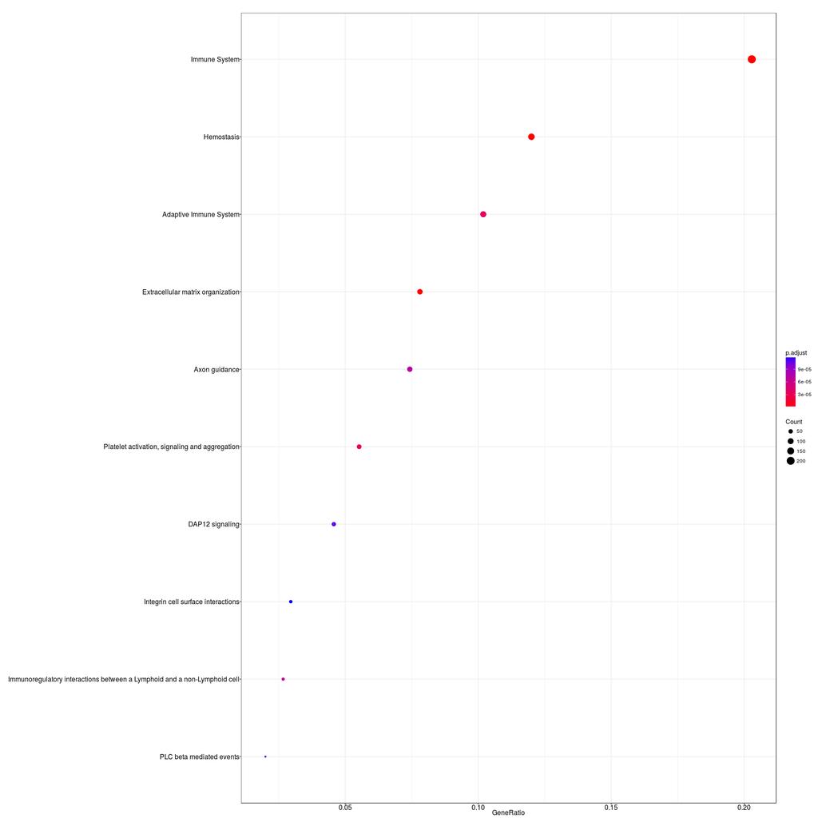

```r
DEG_names <- mapIds(org.Hs.eg.db, keys = rownames(signif),
                    keytype = "REFSEQ", column = "ENTREZID")
enrich <- enrichPathway(DEG_names, minGSSize = 2, maxGSSize = 2000)
write.csv(as.data.frame(enrich), file = "Reactome_DR.csv",
          row.names = FALSE, na = "")
dotplot(enrich)
```

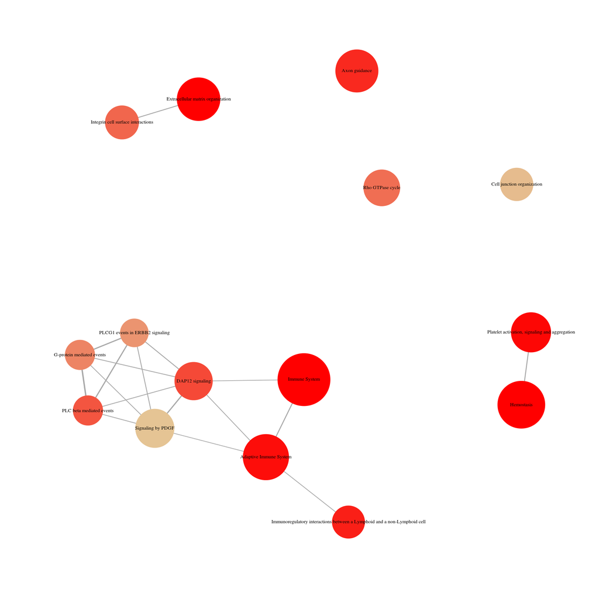

```r
enrichMap(enrich, layout = igraph::layout_nicely,
          vertex.label.cex = 1, n = 15)
```

Now we can observe which pathways are enriched with those genes, there is a functional difference between the genes up and down regulated.

## 10.2 Gene Ontology

We can see the enrichment in the genes ontologies using topGO package:

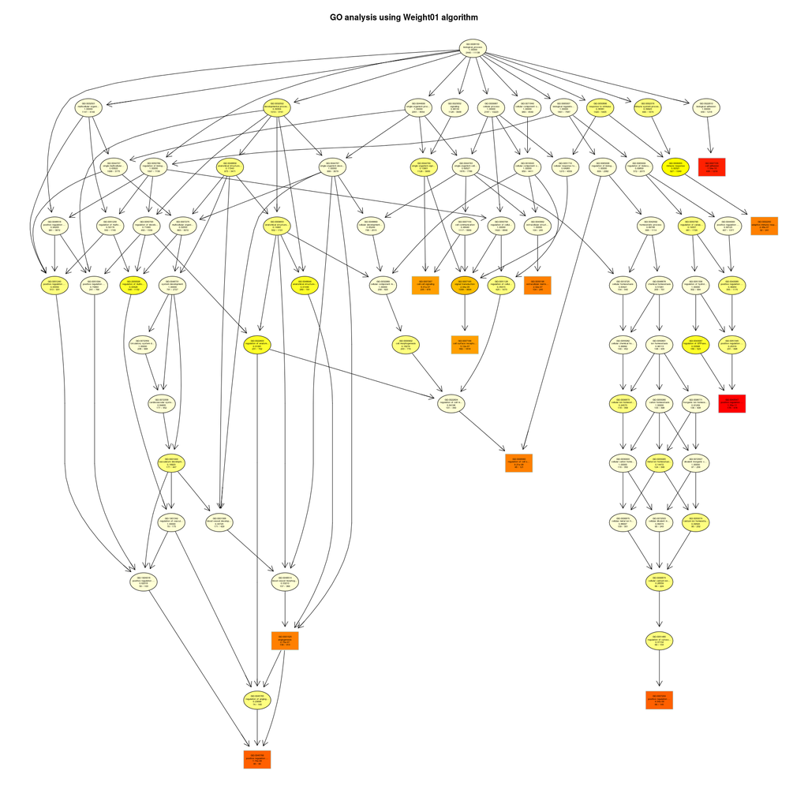

```r
library("topGO")
allGenes <- tt.DR[, "adj.P.Val"]
names(allGenes) <- rownames(tt.DR)
topDiffGenes <- function(x) {
  return(x <= 0.05)
}
idsMapping <- mapIds(org.Hs.eg.db, names(allGenes), "GO", keytype = "REFSEQ",
                     multiVals = "list")
GOdata.bp <- new("topGOdata",
                 ontology = "BP",
                 description = "Biological process of the signature module.",
                 allGenes = allGenes,
                 annot = annFUN.gene2GO, gene2GO = idsMapping,
                 geneSelection = topDiffGenes,
                 nodeSize = 5)
save(GOdata.bp, file = "GO_DR.RData")
resultFisher <- runTest(GOdata.bp, algorithm = "classic", statistic = "fisher")
resultKS.weight <- runTest(GOdata.bp, algorithm = 'weight01', statistic = "ks")
resultKS.elim <- runTest(GOdata.bp, algorithm = "elim", statistic = "ks")

allRes <- GenTable(GOdata.bp, classic = resultFisher,
                   weight01 = resultKS.weight, elim = resultKS.elim,
                   orderBy = "weight01", topNodes = 1000)
allRes <- allRes[allRes$weight01 < 0.05, ]
write.csv(allRes, file = "GO_DR_progression.csv", row.names = FALSE)
head(allRes)
##         GO.ID                                        Term Annotated
## 34 GO:0051056 regulation of small GTPase mediated sign...       229
## 35 GO:0006883             cellular sodium ion homeostasis        11
## 36 GO:0007186 G-protein coupled receptor signaling pat...       493
## 37 GO:0006968                   cellular defense response        34
## 38 GO:0045954 positive regulation of natural killer ce...        13
## 39 GO:0006508                                 proteolysis      1169
##    Significant Expected Rank in weight01 classic weight01    elim
## 34          88    50.17               34 7.8e-09  0.00010 4.1e-05
## 35           6     2.41               35 0.01821  0.00011 0.00011
## 36         154   108.00               36 5.5e-07  0.00011 2.4e-06
## 37          19     7.45               37 1.6e-05  0.00018 0.00018
## 38          10     2.85               38 3.7e-05  0.00022 0.00022
## 39         235   256.09               39 0.94773  0.00022 0.99865
showSigOfNodes(GOdata.bp, score(resultKS.weight), firstSigNodes = 10, useInfo = 'all')
## $dag
## A graphNEL graph with directed edges
## Number of Nodes = 82
## Number of Edges = 148
##
## $complete.dag
## [1] "A graph with 82 nodes."
title(main = "GO analysis using Weight01 algorithm", line = -2)
```